# How do I plot data in Python?

One of the easiest ways to plot data is to use the `matplotlib` library:

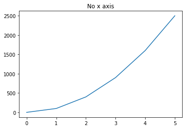

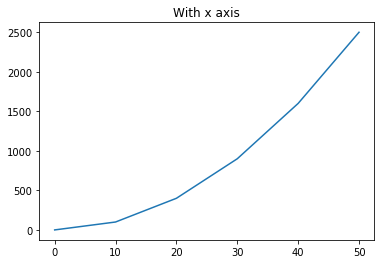

```python
import matplotlib.pyplot as plt

x = [0, 10, 20, 30, 40, 50]
y = [v*v for v in x]

# If no x-axis is provided, x-values are labeled 0, 1, 2, etc.
plt.plot(y)
plt.title('No x axis')
plt.show()

# If provided, x-values will be taken from first argument
plt.plot(x, y)
plt.title('With x axis')
plt.show()
```

# How do I change the default font size in Matplotlib figure?

The font size of individual text entries in a matplotlib figure can usually be adjusted using a dedicated `fontsize` flag. To set the overall default for *all* matplotlib text, you can update the `rcParams` dict that stores default display information:

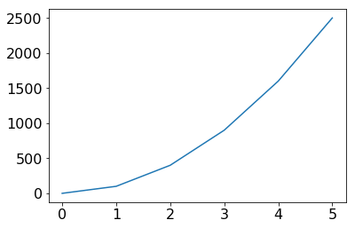

```python
import matplotlib.pyplot as plt

plt.rcParams.update({'font.size': 16})

x = [0, 10, 20, 30, 40, 50]
y = [v*v for v in x]

plt.plot(y)
plt.show()
```

# How do I make subplots in Python / Matplotlib?

Use the `subplots()` command:

- The first argument is the number of rows
- The seconda argument is the number of columns
- The third argument is the number of the active plot (starts at 1)

You can use the `figsize` flag in `plt.figure()` to control the size and aspect ratio of the figure you create. (The default dimensions are nominally in inches.)

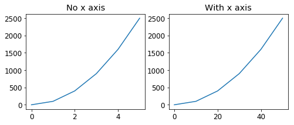

```python
import matplotlib.pyplot as plt

plt.rcParams.update({'font.size': 12})

x = [0, 10, 20, 30, 40, 50]
y = [v*v for v in x]

plt.figure(figsize=(8,3))
ax1 = plt.subplot(1,2,1)
plt.title('No x axis')
plt.plot(y)

ax2 = plt.subplot(1,2,2)
plt.title('With x axis')
plt.plot(x,y)

plt.show()
```

# How do I change the line or marker style in a Matplotlib plot?

The optional argument immediately following the y-axis data controls the line/marker style:

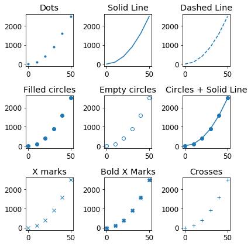

```python
import matplotlib.pyplot as plt

plt.rcParams.update({'font.size': 12})

x = [0, 10, 20, 30, 40, 50]
y = [v*v for v in x]

plt.figure(figsize=(6,6))

plt.subplot(3,3,1)
plt.plot(x, y, '.')
plt.title('Dots')

plt.subplot(3,3,2)
plt.plot(x, y, '-')
plt.title('Solid Line')

plt.subplot(3,3,3)
plt.plot(x, y, '--')
plt.title('Dashed Line')

plt.subplot(3,3,4)
plt.plot(x, y, 'o')
plt.title('Filled circles')

plt.subplot(3,3,5)
plt.plot(x, y, 'o', markerfacecolor='none')
plt.title('Empty circles')

plt.subplot(3,3,6)
plt.plot(x, y, 'o-')
plt.title('Circles + Solid Line')

plt.subplot(3,3,7)
plt.plot(x, y, 'x')
plt.title('X marks')

plt.subplot(3,3,8)
plt.plot(x, y, 'X')
plt.title('Bold X Marks')

plt.subplot(3,3,9)
plt.plot(x, y, '+')
plt.title('Crosses')

plt.tight_layout()
plt.savefig('test.png', dpi=300)
plt.show()
```

# How do I fix crowded axes in a Python/Matplotlib plot?

A quick shortcut is the `plt.tight_layout()` command. This should be called *before* plt.show().

# How do I export a matplotlib figure?

Call the `plt.savefig()` command, as illustrated above for export to the file `test.png`. (You can export to eps file format just by changing the extension.) The `dpi` flag specifies the dots-per-inch. (Increase this number for higher-resolution images.)

Note that `plt.savefig()` should be called *before* calling plt.show().

# How do I change the line or marker color in a Matplotlib plot?

The same argument that controls line/marker style also controls color. Default options include:

- k -- black
- b -- blue
- r -- red
- g -- green
- m -- magenta
- y -- yellow
- w -- white

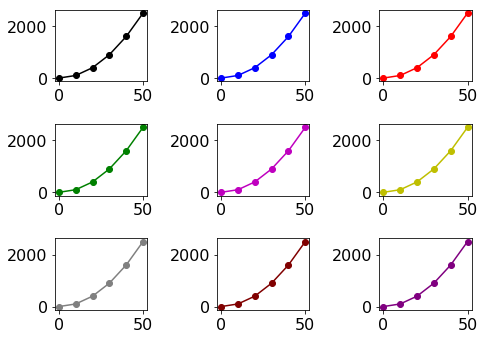

```python
import matplotlib.pyplot as plt

x = [0, 10, 20, 30, 40, 50]
y = [v*v for v in x]


plt.figure(figsize=(7,5))

plt.subplot(3,3,1)
plt.plot(x, y, '-ok')

plt.subplot(3,3,2)
plt.plot(x, y, '-ob')

plt.subplot(3,3,3)
plt.plot(x, y, '-or')

plt.subplot(3,3,4)
plt.plot(x, y, '-og')

plt.subplot(3,3,5)
plt.plot(x, y, '-om')

plt.subplot(3,3,6)
plt.plot(x, y, '-oy')

# Custom: Gray
plt.subplot(3,3,7)
plt.plot(x, y, '-o', color=[0.5,0.5,0.5])

# Custom: Dark red
plt.subplot(3,3,8)
plt.plot(x, y, '-o', color=[0.5,0.0,0.0])

# Custom: Purple
plt.subplot(3,3,9)
plt.plot(x, y, '-o', color=[0.5, 0.0, 0.5])

plt.tight_layout()
plt.show()
```

# How do I change the line width (thickness) of a Matplotlib curve?

Use the `linewidth` flag. E.g.

`plt.plot(vaxis, spec, linewidth=3)`

will plot a line with 3 times the default thickness.

# How do I add custom annotations to a matplotlib figure?

Use the `plt.text` command. The first and second arguments are `x` and `y` coordinates on the plot. The third argument is the string you want placed in the image. You can use the `ha` (horizontal alignment) and `va` (vertical alignment) flags to control where the text is placed relative to the (x,y) point specified.

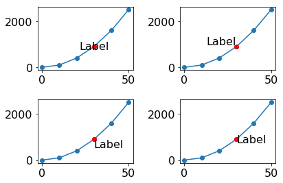

```python
import matplotlib.pyplot as plt

x = [0, 10, 20, 30, 40, 50]
y = [v*v for v in x]

plt.figure()
plt.subplot(2,2,1)
plt.plot(x, y, 'o-')
plt.plot(30, 900, 'or')
plt.text(30, 900, 'Label', fontsize=16, ha='center', va='center')

plt.subplot(2,2,2)
plt.plot(x, y, 'o-')
plt.plot(30, 900, 'or')
plt.text(30, 900, 'Label', fontsize=16, ha='right', va='bottom')

plt.subplot(2,2,3)
plt.plot(x, y, 'o-')
plt.plot(30, 900, 'or')
plt.text(30, 900, 'Label', fontsize=16, ha='left', va='top')

plt.subplot(2,2,4)
plt.plot(x, y, 'o-')
plt.plot(30, 900, 'or')
plt.text(30, 900, 'Label', fontsize=16, ha='left', va='center')
plt.tight_layout()
plt.show()
```

# How do I control data limits in Matplotlib figures?

Use the `plt.xlim()` and `plt.ylim()` commands:

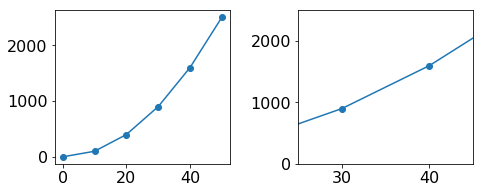

```python
import matplotlib.pyplot as plt

plt.rcParams.update({'font.size': 16})

x = [0, 10, 20, 30, 40, 50]
y = [v*v for v in x]

# Default data limits:
plt.figure(figsize=(7,3))
plt.subplot(1,2,1)
plt.plot(x, y, 'o-')

# Custom data limits:
plt.subplot(1,2,2)
plt.plot(x, y, 'o-')
plt.xlim(25, 45)
plt.ylim(0, 50*50)

plt.tight_layout()
plt.show()
```

# How do I add a legend to a matplotlib figure?

Use the `plt.legend()` command, indicating the text for each data series using the `label` flag. For quality math formatting, you can use LaTex expressions enclosed in dollar signs (`$`).

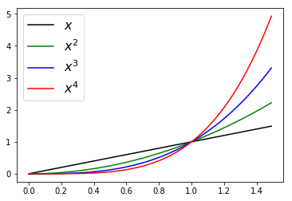

```python
import matplotlib.pyplot as plt

x = [v/100.0 for v in range(0, 150)]
x2 = [v*v for v in x]
x3 = [v*v*v for v in x]
x4 = [v*v*v*v for v in x]

plt.figure()
plt.plot(x, x, '-k', label='$x$')
plt.plot(x, x2, '-g', label='$x^2$')
plt.plot(x, x3, '-b', label='$x^3$')
plt.plot(x, x4, '-r', label='$x^4$')

plt.legend(fontsize=16)
plt.show()
```

# How do I control the location of a matplotlib legend?

Use the `loc` flag to `plt.legend()`. Options include

- best
- upper right
- upper left
- lower left
- lower right
- right
- center left
- center right
- lower center
- upper center
- center

As illustrated below, you can also use the `ncol` flag to set the number of columns through which the labels are distributed.

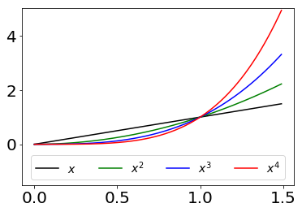

```python
import matplotlib.pyplot as plt

x = [v/100.0 for v in range(0, 150)]
x2 = [v*v for v in x]
x3 = [v*v*v for v in x]
x4 = [v*v*v*v for v in x]

plt.figure()
plt.plot(x, x, '-k', label='$x$')
plt.plot(x, x2, '-g', label='$x^2$')
plt.plot(x, x3, '-b', label='$x^3$')
plt.plot(x, x4, '-r', label='$x^4$')
plt.ylim([-1.5, 5])

plt.legend(fontsize=14, loc='lower center', ncol=4)
plt.show()
```

# How do I add axis labels to a Matplotlib figure?

Use the `plt.xlabel()` and `plt.ylabel()` commands. You can use LaTex in these argument, but you'll need to use a double backslash (`\\`) in place of each single backslash (`\`) in LaTex variables. (The first backslash is an escape sequence to prevent the interpreter from reading it as the start of a special character.)

E.g., normal LaTex syntax codes for the Angstrom symbol by the text `\AA`; to use this symbol in a Matplotlib label argument, you'll need to enter instead `\\AA`.

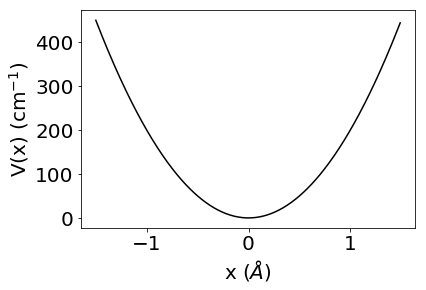

```python
import matplotlib.pyplot as plt

plt.rcParams.update({'font.size': 20})

x = [v/100.0 for v in range(-150, 150)]
y = [200*v*v for v in x]

plt.figure()
plt.plot(x, y, 'k')

plt.xlabel('x ($\\AA$)')
plt.ylabel('V(x) (cm$^{-1})$')

plt.show()
```

# How do I control the location of matplotlib axes?

Use

- `plt.gca().xaxis.set_label_position("top")`
- `plt.gca().xaxis.tick_top()`

to move the x axis to the top of the plot. Use

- `plt.gca().yaxis.set_label_position("right")`
- `plt.gca().yaxis.tick_right()`

to move the y axis to the right-hand side. (The same commands work in reverse and in combination with each other.)

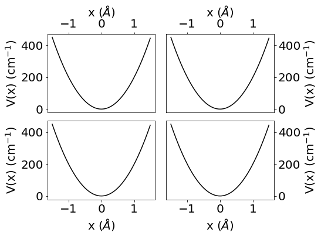

```python
import matplotlib.pyplot as plt

plt.rcParams.update({'font.size': 20})
x = [v/100.0 for v in range(-150, 150)]
y = [200*v*v for v in x]

plt.figure(figsize=(8,6))

plt.subplot(2,2,1)
plt.plot(x, y, 'k')
plt.xlabel('x ($\\AA$)')
plt.ylabel('V(x) (cm$^{-1})$')
plt.gca().xaxis.set_label_position("top")
plt.gca().xaxis.tick_top()

plt.subplot(2,2,2)
plt.plot(x, y, 'k')
plt.xlabel('x ($\\AA$)')
plt.ylabel('V(x) (cm$^{-1})$')

# Move x axis to top of plot
plt.gca().xaxis.set_label_position("top")
plt.gca().xaxis.tick_top()

# Move y-axis to the right of plot
plt.gca().yaxis.set_label_position("right")
plt.gca().yaxis.tick_right()

# We'll leave this one set to the defaults
plt.subplot(2,2,3)
plt.plot(x, y, 'k')
plt.xlabel('x ($\\AA$)')
plt.ylabel('V(x) (cm$^{-1})$')

plt.subplot(2,2,4)
plt.plot(x, y, 'k')
plt.xlabel('x ($\\AA$)')
plt.ylabel('V(x) (cm$^{-1})$')

# Move y-axis to the right of plot
plt.gca().yaxis.set_label_position("right")
plt.gca().yaxis.tick_right()

plt.tight_layout()

# The subplots_adjust() command controls horizontal
# ("width") space and vertical ("height") space
# between subplots. It's better to call this *after*
# plt.tight_layout() so that the tight_layout function
# first ensures all labels fall within the bounds
# of the figure. (Otherwise, some labels may be)
# out of the figure boundaries when exported using
# plt.savefig().)
plt.subplots_adjust(wspace=0.1)
plt.subplots_adjust(hspace=0.1)

plt.savefig('test.png')

plt.show()
```

# How do I make tick marks display inside a matplotlib axis?

Use `plt.gca().tick_params(direction='in')`. You can also use `out` to make ticks point out or `inout` to make ticks that point both in and out.

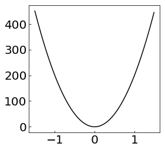

```python
import matplotlib.pyplot as plt

plt.rcParams.update({'font.size': 20})
x = [v/100.0 for v in range(-150, 150)]
y = [200*v*v for v in x]

plt.figure(figsize=(4,4))

plt.plot(x, y, 'k')
plt.gca().tick_params(direction='in')
plt.show()
```

# How do I make filled curves in Matplotlib plots ?

Use the `plt.fill_between()`. The first two arguments are as in `plt.plot()`. The `y2=` flag should either be a vector or scalar giving the lower boundary for filling. The default value is `y2=0`, which will fill down/up to the x axis.

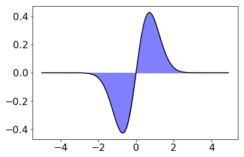

```python
import matplotlib.pyplot as plt
import numpy as np

x = np.arange(-5, 5, 0.1)
y = x*np.exp(-x*x)

# We add a solid line also to make the edges clear
plt.plot(x, y, 'k-')
plt.fill_between(x, y, y2=0, color=[0.5, 0.5, 1.0])
plt.show()
```

# How do I make a transparent fill in Matplotlib?

Use the `alpha` flag, a number between 0 (transparent) and 1 (opaque).

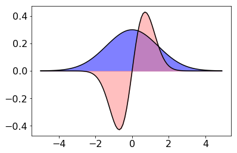

```python
import matplotlib.pyplot as plt
import numpy as np

x = np.arange(-5, 5, 0.1)
yfore = x*np.exp(-x*x)
yback = 0.3*np.exp(-x*x/4)

# We'll add an opaque Gaussian in the background
plt.plot(x, yback, 'k-')
plt.fill_between(x, yback, y2=0, color=[0.5, 0.5, 1.0], alpha=1.0)

# And a half-transparent Gaussian derivative in the foreground
plt.plot(x, yfore, 'k-')
plt.fill_between(x, yfore, y2=0, color=[1.0, 0.5, 0.5], alpha=0.5)
plt.show()
```

# How do I change the background / foreground order of Matplotlib curves ?

Use the `zorder` flag. Lower values place objects farther toward the back.

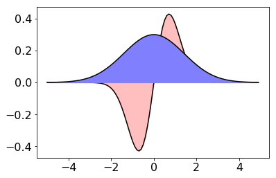

```python
import matplotlib.pyplot as plt
import numpy as np

x = np.arange(-5, 5, 0.1)
yfore = x*np.exp(-x*x)
yback = 0.3*np.exp(-x*x/4)

# The Gaussian is moved to the front when zorder=1
plt.plot(x, yback, 'k-', zorder=1)
plt.fill_between(x, yback, y2=0, color=[0.5, 0.5, 1.0], alpha=1.0, zorder=1)

# The Gaussian derivative is now moved to the background since zorder=0
plt.plot(x, yfore, 'k-', zorder=0)
plt.fill_between(x, yfore, y2=0, color=[1.0, 0.5, 0.5], alpha=0.5, zorder=0)
plt.show()
```

# How do I make a waterfall plot in Python / Matplotlib?

When comparing many curves (or spectra) over the same x-axis range, it's often useful to "stack" the spectra so that features can be easily compared without too much overlap. There's no one "right" way to do this, but a very simple method is to write a `for()` loop that plots each curve individually, with an offset `shift*n` added to each consecutive curve.

How do you choose the right `shift` value to separate the curves? That's art as much as science, but a good start is to set `shift` equal to 1/2 of the difference between maximum and minimum values in your set of curves.

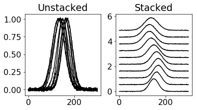

```python
# This will be our x-axis
xaxis = np.arange(0, 300, 1.0)

# This is the number of points on the x-axis
Npts = len(xaxis)

# This will be the number of curves we "stack"
Ncurves = 10

# This will hold the curves, i.e., the y-axis data
Curves = np.zeros((Npts,Ncurves))
for n in range(0, Ncurves):

    # sigma sets the width of the curve
    sigma = 20 + n

    # mu will be the x-axis location of the peak
    mu = np.mean(xaxis) + 20*np.sin(2*np.pi*n/Ncurves)

    # Generate some noise to mimic experimental data
    noise = 0.01*np.random.normal(size=(Npts,))

    # Generate the curve
    Curves[:,n] = np.exp(-(xaxis-mu)**2/(2*sigma**2)) + noise


# Now let's compare stacked and un-stacked representations
plt.figure(figsize=(6,3))
plt.subplot(1,2,1)
plt.plot(xaxis, Curves, 'k')
plt.title("Unstacked")

plt.subplot(1,2,2)
plt.title('Stacked')

# The value "shift" controls the spacing between the curves.
# This parameter may be changed from figure to figure, but
# a useful starting point 1/2 the difference between max and
# min values of the data set.
shift = 0.5*np.max(np.max(Curves)) - np.min(np.min(Curves))
for n in range(0, Ncurves):

    # We add an offset shift*n to each consecutive curve.
    plt.plot(xaxis, Curves[:,n]+shift*n, 'k')
plt.show()
```

# How do I use colormaps to color curves in Matplotlib?

If you don't specify line colors explicitly, matplotlib will assign them according to a predefined "colormap" -- a sequence of colors that can defines the color of each object in a Matplotlib figure. The code below illustrates how to extract a list of such colors explicitly from the pre-defined colormap options. (See https://matplotlib.org/stable/gallery/color/colormap_reference.html). The key line of code is:

`Colors = mpl.cm.copper(np.linspace(0, 0.8, Ncurves))`

`Colors` will now be an Ncurves-by-4 NumPy array; each row can be passed as a color to `plt.plot()`. (The fourth value is the `alpha` channel indicating transparency.) Thus

`plt.plot(xaxis, Curves[:,n], color=Colors[n])`

will generate a curve with the color defined by `Colors[n]`.

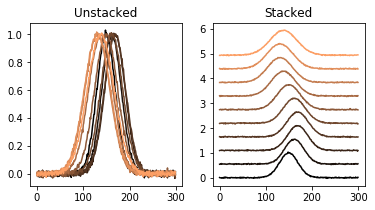

[output not shown]

```python
import matplotlib as mpl
import matplotlib.pyplot as plt
import numpy as np

# This will be our x-axis
xaxis = np.arange(0, 300, 1.0)

# This is the number of points on the x-axis
Npts = len(xaxis)

# This will be the number of curves we "stack"
Ncurves = 10

# This will hold the curves, i.e., the y-axis data
Curves = np.zeros((Npts,Ncurves))
for n in range(0, Ncurves):

    # sigma sets the width of the curve
    sigma = 20 + n

    # mu will be the x-axis location of the peak
    mu = np.mean(xaxis) + 20*np.sin(2*np.pi*n/Ncurves)

    # Generate some noise to mimic experimental data
    noise = 0.01*np.random.normal(size=(Npts,))

    # Generate the curve
    Curves[:,n] = np.exp(-(xaxis-mu)**2/(2*sigma**2)) + noise

# Get an array of colors for each curve.
# The keyword "copper" here can be replaced with any of the options
# listed on this page:
# https://matplotlib.org/stable/gallery/color/colormap_reference.html
# The two arguments set to "0" and "0.8" below can be chosen anywhere
# from 0 to 1. They control which part of the colormap sequence is
# reflected in your curves. In this case, we set the uppber bound to
# 0.8 instead of 1 because the top end of the "copper" colormap
# is difficult to see against a white background.
Colors = mpl.cm.copper(np.linspace(0, 0.8, Ncurves))

# Now let's compare stacked and un-stacked representations
plt.figure(figsize=(6,3))
plt.subplot(1,2,1)
for n in range(0, Ncurves):
    plt.plot(xaxis, Curves[:,n], color=Colors[n])
plt.title("Unstacked")

plt.subplot(1,2,2)
plt.title('Stacked')
shift = 0.5*np.max(np.max(Curves)) - np.min(np.min(Curves))
for n in range(0, Ncurves):

    # We add an offset shift*n to each consecutive curve.
    plt.plot(xaxis, Curves[:,n]+shift*n, color=Colors[n])
plt.show()
```

# How do I set the aspect ratio of Matplotlib axes?

Use the `plt.gca().set_aspect()` command. `plt.gca()` calls the current `axis` object that controls axis labels, frames, legends, aspect ratios, and much more. The `set_aspect()` command allows you to control the relative scaling of the `x` and `y` axes on a given plot.

`plt.gca().set_aspect(1)` means that the display step-sizes for the x and y axes will be the same. `plt.gca().set_aspect(2)` means that the display step-size for the `y` axis will be twice as large as the display step-size for the `x` axis. `plt.gca().set_aspect(0.5)` means that the display step-size for the `x` axis will be twice as large as the display step-size for the `y` axis.

This is particularly useful if you want to prepare a square plot with the same data limits along both axes. In the example, below, we use the NumPy library and the `plt.contourf` function to prepare a filled contour plot of a Gaussian function, with equal step sizes along the `x` and `y` axes.

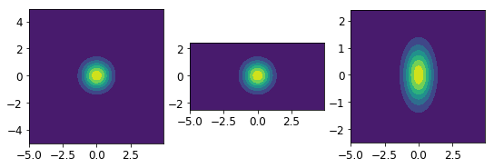

```python
import numpy as np

plt.rcParams.update({'font.size': 12})

plt.figure(figsize=(9,3))

#################################################################
## First, we'll create a perfectly square image of a Gaussian. ##

plt.subplot(1,3,1)

# These will be the sampling points along x and y axes
x = np.arange(-5, 5, 0.1)
y = np.arange(-5, 5, 0.1)

# np.meshgrid() creates a grid of data points with all
# possible combinations of x-values and y-values.
xx,yy = np.meshgrid(x, y)

# plt.contourf() prepares filled contour plots.
# np.exp() takes the exponential of the argument.
# In this cases, this produces a Gaussian function.
plt.contourf(xx, yy, np.exp(-(xx*xx + yy*yy)))

# Setting the aspect ratio equal
plt.gca().set_aspect('equal')

#################################################################
## Now let's see what happens if x and y have different limits ##
plt.subplot(1,3,2)
x = np.arange(-5, 5, 0.1)
y = np.arange(-2.5, 2.5, 0.1)

xx,yy = np.meshgrid(x, y)
plt.contourf(xx, yy, np.exp(-(xx*xx + yy*yy)))
plt.gca().set_aspect('equal')

# The displayed step size along x and y axes is still the same, so
# it's obvious that the y axis covers less range.


##################################################################
## We can create a square plot again by "stretching" the y axis ##
plt.subplot(1,3,3)
x = np.arange(-5, 5, 0.1)
y = np.arange(-2.5, 2.5, 0.1)

xx,yy = np.meshgrid(x, y)
plt.contourf(xx, yy, np.exp(-(xx*xx + yy*yy)))

# This means that the y-axis display stepsize will be twice as
# big as the x axis. The data limits remain unchanged.
plt.gca().set_aspect(2)


plt.show()
```